# C-MAPSS_assignment_10

1. Download C-MAPSS dataset https://data.nasa.gov/dataset/cmapss-jet-engine-simulated-data. The CMAPSS dataset has vibration, temperature, pressures, flow rate and operating conditions of a turbofan engine.
2. Understanding the data by parsing text to pandas data frames and label RUL by creating a target column.
3. Store these as csv/excel files in a folder. Visualize the degradation trends in the CMAPSS dataset. You should normalize the data using a suitable normalizer and remove non informative data columns.
4. Prepare a short writeup of which columns you are removing and why.
5. Generate sliding windows as time-series sequences and keep them in a separate files in separate folders.
6. For all the above compute rolling statistics, trend feature like slope monotonicity, health index creation and use PCA to decide which columns to drop. [ check for sensor1, sensor5, sensor6, sensor10, sensor16, sensor18, sensor19 ]

   Use FD001 -> simple (1 operating condition, low noise FD004 -> complex (multiple conditions, high noise)

   Weeks 1–2 → FD001 Weeks 3–4 → FD004 + transfer tests RUL = max_cycle - current_cycle RUL = min(RUL, 125) This is a standard practice in literature window_size = 30 features ≈ 14–18 Loss Function :

   MSELoss (primary)
7. Implement a three layer neural network using Input vector (~420–540 features), Architecture : Dense(128) → ReLU, Dense(64) → ReLU, Dense(1) [output layer]
8. Present your RMSE results.
- Keep all data files, all implementations on neural networks will be using the processed C-MAPSS datasets

```python
import pandas as pd
import numpy as np
import matplotlib.pyplot as plt
import os
```

### Defining Column Names & Load Data

```python
# C-MAPSS has 26 columns: unit, cycle, 3 op settings, 21 sensors

col_names = ['unit_id', 'cycle',
             'op_setting1', 'op_setting2', 'op_setting3',
             'sensor1','sensor2','sensor3','sensor4','sensor5',
             'sensor6','sensor7','sensor8','sensor9','sensor10',
             'sensor11','sensor12','sensor13','sensor14','sensor15',
             'sensor16','sensor17','sensor18','sensor19','sensor20','sensor21']

def load_cmapss(file_path):
    df = pd.read_csv(file_path, sep='\s+', header=None, names=col_names)
    return df

# Load FD001 train and test
train_df = load_cmapss('C-MAPSS/CMAPSSData/train_FD001.txt')
test_df  = load_cmapss('C-MAPSS/CMAPSSData/test_FD001.txt')
rul_df   = pd.read_csv('C-MAPSS/CMAPSSData/RUL_FD001.txt', header=None, names=['RUL'])

print(train_df.shape)
train_df.head()
```

```
(20631, 26)
```

|  | unit_id | cycle | op_setting1 | op_setting2 | op_setting3 | sensor1 | sensor2 | sensor3 | sensor4 | sensor5 | ... | sensor12 | sensor13 | sensor14 | sensor15 | sensor16 | sensor17 | sensor18 | sensor19 | sensor20 | sensor21 |
| --- | --- | --- | --- | --- | --- | --- | --- | --- | --- | --- | --- | --- | --- | --- | --- | --- | --- | --- | --- | --- | --- |
| 0 | 1 | 1 | -0.0007 | -0.0004 | 100.0 | 518.67 | 641.82 | 1589.70 | 1400.60 | 14.62 | ... | 521.66 | 2388.02 | 8138.62 | 8.4195 | 0.03 | 392 | 2388 | 100.0 | 39.06 | 23.4190 |
| 1 | 1 | 2 | 0.0019 | -0.0003 | 100.0 | 518.67 | 642.15 | 1591.82 | 1403.14 | 14.62 | ... | 522.28 | 2388.07 | 8131.49 | 8.4318 | 0.03 | 392 | 2388 | 100.0 | 39.00 | 23.4236 |
| 2 | 1 | 3 | -0.0043 | 0.0003 | 100.0 | 518.67 | 642.35 | 1587.99 | 1404.20 | 14.62 | ... | 522.42 | 2388.03 | 8133.23 | 8.4178 | 0.03 | 390 | 2388 | 100.0 | 38.95 | 23.3442 |
| 3 | 1 | 4 | 0.0007 | 0.0000 | 100.0 | 518.67 | 642.35 | 1582.79 | 1401.87 | 14.62 | ... | 522.86 | 2388.08 | 8133.83 | 8.3682 | 0.03 | 392 | 2388 | 100.0 | 38.88 | 23.3739 |
| 4 | 1 | 5 | -0.0019 | -0.0002 | 100.0 | 518.67 | 642.37 | 1582.85 | 1406.22 | 14.62 | ... | 522.19 | 2388.04 | 8133.80 | 8.4294 | 0.03 | 393 | 2388 | 100.0 | 38.90 | 23.4044 |

5 rows × 26 columns

### Adding RUL column to training data

```python
# RUL = max_cycle for that engine - current cycle
def add_rul(df):
    max_cycles = df.groupby('unit_id')['cycle'].max().reset_index()
    max_cycles.columns = ['unit_id', 'max_cycle']
    df = df.merge(max_cycles, on='unit_id')
    df['RUL'] = df['max_cycle'] - df['cycle']
    df['RUL'] = df['RUL'].clip(upper=125)   # cap at 125
    df.drop(columns=['max_cycle'], inplace=True)
    return df

train_df = add_rul(train_df)
print(train_df[['unit_id','cycle','RUL']].head(10))
```

```
   unit_id  cycle  RUL
0        1      1  125
1        1      2  125
2        1      3  125
3        1      4  125
4        1      5  125
5        1      6  125
6        1      7  125
7        1      8  125
8        1      9  125
9        1     10  125
```

### Adding RUL to Test Data (useing the provided RUL file)

```python
# For test set, the last cycle's RUL is given in RUL_FD001.txt


def add_rul_test(df, rul_df):
    # rul_df has one RUL value per engine (the RUL at the LAST recorded cycle)
    last_cycles = df.groupby('unit_id')['cycle'].max().reset_index()
    last_cycles.columns = ['unit_id', 'last_cycle']
    last_cycles['true_rul_at_end'] = rul_df['RUL'].values

    df = df.merge(last_cycles, on='unit_id')
    df['RUL'] = (df['last_cycle'] - df['cycle']) + df['true_rul_at_end']
    df['RUL'] = df['RUL'].clip(upper=125)
    df.drop(columns=['last_cycle', 'true_rul_at_end'], inplace=True)
    return df

test_df = add_rul_test(test_df, rul_df)
test_df[['unit_id','cycle','RUL']].head(10)
```

|  | unit_id | cycle | RUL |
| --- | --- | --- | --- |
| 0 | 1 | 1 | 125 |
| 1 | 1 | 2 | 125 |
| 2 | 1 | 3 | 125 |
| 3 | 1 | 4 | 125 |
| 4 | 1 | 5 | 125 |
| 5 | 1 | 6 | 125 |
| 6 | 1 | 7 | 125 |
| 7 | 1 | 8 | 125 |
| 8 | 1 | 9 | 125 |
| 9 | 1 | 10 | 125 |

### Saving data to CSV

```python
os.makedirs('C-MAPSS/CMAPSSData/processed', exist_ok=True)

train_df.to_csv('C-MAPSS/CMAPSSData/processed/train_FD001.csv', index=False)
test_df.to_csv('C-MAPSS/CMAPSSData/processed/test_FD001.csv', index=False)

print("Saved!")
print(f"Train shape: {train_df.shape}")
print(f"Test shape:  {test_df.shape}")
```

```
Saved!
Train shape: (20631, 27)
Test shape:  (13096, 27)
```

## Visualize Sensor Degradation Trends

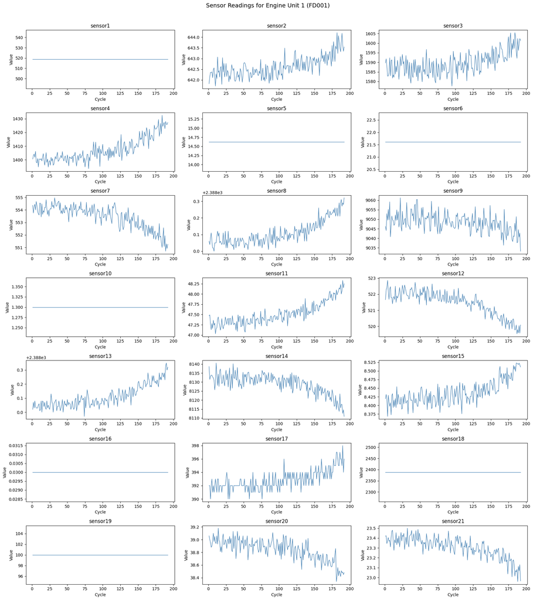

```python
# Plot a few sensors for a single engine to see degradation
sensor_cols = [f'sensor{i}' for i in range(1, 22)]

fig, axes = plt.subplots(7, 3, figsize=(18, 20))
axes = axes.flatten()

unit1 = train_df[train_df['unit_id'] == 1].reset_index(drop=True)

for i, sensor in enumerate(sensor_cols):
    axes[i].plot(unit1['cycle'], unit1[sensor], color='steelblue', linewidth=1)
    axes[i].set_title(sensor)
    axes[i].set_xlabel('Cycle')
    axes[i].set_ylabel('Value')

plt.suptitle('Sensor Readings for Engine Unit 1 (FD001)', fontsize=14, y=1.01)
plt.tight_layout()
plt.savefig('C-MAPSS/CMAPSSData/processed/sensor_trends.png', dpi=150, bbox_inches='tight')
plt.show()
```

```python
# Sensors with near-zero std across the whole dataset carry no information
sensor_std = train_df[sensor_cols].std()
print("Standard Deviation per Sensor:")
print(sensor_std.round(6))

# Flag sensors with very low std
low_std_sensors = sensor_std[sensor_std < 0.01].index.tolist()
print(f"\nLow-variance sensors (std < 0.01): {low_std_sensors}")
```

```
Standard Deviation per Sensor:
sensor1      0.000000
sensor2      0.500053
sensor3      6.131150
sensor4      9.000605
sensor5      0.000000
sensor6      0.001389
sensor7      0.885092
sensor8      0.070985
sensor9     22.082880
sensor10     0.000000
sensor11     0.267087
sensor12     0.737553
sensor13     0.071919
sensor14    19.076176
sensor15     0.037505
sensor16     0.000000
sensor17     1.548763
sensor18     0.000000
sensor19     0.000000
sensor20     0.180746
sensor21     0.108251
dtype: float64

Low-variance sensors (std < 0.01): ['sensor1', 'sensor5', 'sensor6', 'sensor10', 'sensor16', 'sensor18', 'sensor19']
```

### dROPPING non-informative sensors

```python
sensors_to_drop = ['sensor1', 'sensor5', 'sensor6', 'sensor10', 'sensor16', 'sensor18', 'sensor19']

train_clean = train_df.drop(columns=sensors_to_drop)
test_clean  = test_df.drop(columns=sensors_to_drop)

remaining_sensors = [c for c in train_clean.columns if 'sensor' in c]
print(f"Remaining sensors ({len(remaining_sensors)}): {remaining_sensors}")
print(f"Train shape after dropping: {train_clean.shape}")
```

```
Remaining sensors (14): ['sensor2', 'sensor3', 'sensor4', 'sensor7', 'sensor8', 'sensor9', 'sensor11', 'sensor12', 'sensor13', 'sensor14', 'sensor15', 'sensor17', 'sensor20', 'sensor21']
Train shape after dropping: (20631, 20)
```

### Normalize the Sensor Columns

```python
from sklearn.preprocessing import MinMaxScaler

feature_cols = [c for c in train_clean.columns if c not in ['unit_id', 'cycle', 'RUL']]

scaler = MinMaxScaler()
train_clean[feature_cols] = scaler.fit_transform(train_clean[feature_cols])

# Use SAME scaler on test (fit only on train — important!)
test_clean[feature_cols] = scaler.transform(test_clean[feature_cols])

print("Normalized! Sample:")
train_clean[feature_cols].describe().round(3)
```

```
Normalized! Sample:
```

|  | op_setting1 | op_setting2 | op_setting3 | sensor2 | sensor3 | sensor4 | sensor7 | sensor8 | sensor9 | sensor11 | sensor12 | sensor13 | sensor14 | sensor15 | sensor17 | sensor20 | sensor21 |
| --- | --- | --- | --- | --- | --- | --- | --- | --- | --- | --- | --- | --- | --- | --- | --- | --- | --- |
| count | 20631.000 | 20631.000 | 20631.0 | 20631.000 | 20631.000 | 20631.000 | 20631.000 | 20631.000 | 20631.000 | 20631.000 | 20631.000 | 20631.000 | 20631.000 | 20631.000 | 20631.000 | 20631.000 | 20631.000 |
| mean | 0.499 | 0.502 | 0.0 | 0.443 | 0.425 | 0.450 | 0.566 | 0.298 | 0.195 | 0.411 | 0.581 | 0.318 | 0.226 | 0.451 | 0.434 | 0.524 | 0.546 |
| std | 0.126 | 0.244 | 0.0 | 0.151 | 0.134 | 0.152 | 0.143 | 0.108 | 0.099 | 0.159 | 0.157 | 0.106 | 0.098 | 0.144 | 0.129 | 0.140 | 0.149 |
| min | 0.000 | 0.000 | 0.0 | 0.000 | 0.000 | 0.000 | 0.000 | 0.000 | 0.000 | 0.000 | 0.000 | 0.000 | 0.000 | 0.000 | 0.000 | 0.000 | 0.000 |
| 25% | 0.414 | 0.333 | 0.0 | 0.336 | 0.332 | 0.339 | 0.477 | 0.227 | 0.141 | 0.298 | 0.484 | 0.235 | 0.172 | 0.346 | 0.333 | 0.434 | 0.452 |
| 50% | 0.500 | 0.500 | 0.0 | 0.431 | 0.416 | 0.435 | 0.578 | 0.288 | 0.175 | 0.393 | 0.595 | 0.309 | 0.210 | 0.439 | 0.417 | 0.535 | 0.557 |
| 75% | 0.586 | 0.750 | 0.0 | 0.539 | 0.509 | 0.545 | 0.670 | 0.364 | 0.214 | 0.506 | 0.695 | 0.382 | 0.250 | 0.541 | 0.500 | 0.628 | 0.653 |
| max | 1.000 | 1.000 | 0.0 | 1.000 | 1.000 | 1.000 | 1.000 | 1.000 | 1.000 | 1.000 | 1.000 | 1.000 | 1.000 | 1.000 | 1.000 | 1.000 | 1.000 |

```python
train_clean.to_csv('C-MAPSS/CMAPSSData/processed/train_FD001_clean.csv', index=False)
test_clean.to_csv('C-MAPSS/CMAPSSData/processed/test_FD001_clean.csv', index=False)

print(f"Clean train shape: {train_clean.shape}")
print(f"Clean test shape:  {test_clean.shape}")
print(f"Feature columns: {feature_cols}")
```

```
Clean train shape: (20631, 20)
Clean test shape:  (13096, 20)
Feature columns: ['op_setting1', 'op_setting2', 'op_setting3', 'sensor2', 'sensor3', 'sensor4', 'sensor7', 'sensor8', 'sensor9', 'sensor11', 'sensor12', 'sensor13', 'sensor14', 'sensor15', 'sensor17', 'sensor20', 'sensor21']
```

## Sliding Windows

```python
WINDOW_SIZE = 30

def create_windows(df, window_size, feature_cols):
    X, y = [], []

    for unit_id in df['unit_id'].unique():
        unit_data = df[df['unit_id'] == unit_id].reset_index(drop=True)

        # Need at least window_size rows to form one sample
        if len(unit_data) < window_size:
            continue

        for i in range(len(unit_data) - window_size + 1):
            window = unit_data[feature_cols].iloc[i : i + window_size].values  # (30, 17)
            rul    = unit_data['RUL'].iloc[i + window_size - 1]                # RUL at last step
            X.append(window)
            y.append(rul)

    return np.array(X), np.array(y)

feature_cols = [c for c in train_clean.columns if c not in ['unit_id', 'cycle', 'RUL']]

X_train, y_train = create_windows(train_clean, WINDOW_SIZE, feature_cols)
X_test,  y_test  = create_windows(test_clean,  WINDOW_SIZE, feature_cols)

print(f"X_train shape : {X_train.shape}")   # (samples, 30, 17)
print(f"y_train shape : {y_train.shape}")
print(f"X_test shape  : {X_test.shape}")
print(f"y_test shape  : {y_test.shape}")
```

```
X_train shape : (17731, 30, 17)
y_train shape : (17731,)
X_test shape  : (10196, 30, 17)
y_test shape  : (10196,)
```

```python
# We use a Dense (fully connected) network for the assignment
# So we flatten (30, 17) → (510,) per sample

X_train_flat = X_train.reshape(X_train.shape[0], -1)
X_test_flat  = X_test.reshape(X_test.shape[0],  -1)

print(f"Flattened X_train : {X_train_flat.shape}")  # (samples, 510)
print(f"Flattened X_test  : {X_test_flat.shape}")
print(f"Input vector size : {X_train_flat.shape[1]} features ")
```

```
Flattened X_train : (17731, 510)
Flattened X_test  : (10196, 510)
Input vector size : 510 features
```

## Saving windows to separate folder

```python
import os

windows_dir = 'C-MAPSS/CMAPSSData/windows'
os.makedirs(windows_dir, exist_ok=True)

np.save(os.path.join(windows_dir, 'X_train.npy'), X_train_flat)
np.save(os.path.join(windows_dir, 'y_train.npy'), y_train)
np.save(os.path.join(windows_dir, 'X_test.npy'),  X_test_flat)
np.save(os.path.join(windows_dir, 'y_test.npy'),  y_test)

print("Saved windows!")
print(f"\nFolder contents:")
for f in os.listdir(windows_dir):
    size = os.path.getsize(os.path.join(windows_dir, f)) / 1024
    print(f"  {f}  →  {size:.1f} KB")
```

```
Saved windows!

Folder contents:
  X_test.npy  →  40624.8 KB
  y_test.npy  →  79.8 KB
  y_train.npy  →  138.6 KB
  X_train.npy  →  70647.1 KB
```

## NN

### Loading windows

```python
import numpy as np

windows_dir = 'C-MAPSS/CMAPSSData/windows'

X_train = np.load(f'{windows_dir}/X_train.npy')
y_train = np.load(f'{windows_dir}/y_train.npy')
X_test  = np.load(f'{windows_dir}/X_test.npy')
y_test  = np.load(f'{windows_dir}/y_test.npy')

print(f"X_train : {X_train.shape}")
print(f"y_train : {y_train.shape}")
print(f"X_test  : {X_test.shape}")
print(f"y_test  : {y_test.shape}")
```

```
X_train : (17731, 510)
y_train : (17731,)
X_test  : (10196, 510)
y_test  : (10196,)
```

## Model

```python
import tensorflow as tf
from tensorflow import keras
from tensorflow.keras import layers

print(f"TensorFlow version: {tf.__version__}")

input_dim = X_train.shape[1]  # 510

def build_model(input_dim):
    model = keras.Sequential([
        # Layer 1
        layers.Dense(128, activation='relu', input_shape=(input_dim,), name='dense_1'),
        layers.BatchNormalization(),
        layers.Dropout(0.2),

        # Layer 2
        layers.Dense(64, activation='relu', name='dense_2'),
        layers.BatchNormalization(),
        layers.Dropout(0.2),

        # Output layer
        layers.Dense(1, name='output')   # RUL prediction (regression)
    ])
    return model

model = build_model(input_dim)
model.summary()
```

[output not shown]

```
TensorFlow version: 2.20.0
```

```
Model: "sequential"
```

```
┏━━━━━━━━━━━━━━━━━━━━━━━━━━━━━━━━━┳━━━━━━━━━━━━━━━━━━━━━━━━┳━━━━━━━━━━━━━━━┓
┃ Layer (type)                    ┃ Output Shape           ┃       Param # ┃
┡━━━━━━━━━━━━━━━━━━━━━━━━━━━━━━━━━╇━━━━━━━━━━━━━━━━━━━━━━━━╇━━━━━━━━━━━━━━━┩
│ dense_1 (Dense)                 │ (None, 128)            │        65,408 │
├─────────────────────────────────┼────────────────────────┼───────────────┤
│ batch_normalization             │ (None, 128)            │           512 │
│ (BatchNormalization)            │                        │               │
├─────────────────────────────────┼────────────────────────┼───────────────┤
│ dropout (Dropout)               │ (None, 128)            │             0 │
├─────────────────────────────────┼────────────────────────┼───────────────┤
│ dense_2 (Dense)                 │ (None, 64)             │         8,256 │
├─────────────────────────────────┼────────────────────────┼───────────────┤
│ batch_normalization_1           │ (None, 64)             │           256 │
│ (BatchNormalization)            │                        │               │
├─────────────────────────────────┼────────────────────────┼───────────────┤
│ dropout_1 (Dropout)             │ (None, 64)             │             0 │
├─────────────────────────────────┼────────────────────────┼───────────────┤
│ output (Dense)                  │ (None, 1)              │            65 │
└─────────────────────────────────┴────────────────────────┴───────────────┘
```

```
 Total params: 74,497 (291.00 KB)
```

```
 Trainable params: 74,113 (289.50 KB)
```

```
 Non-trainable params: 384 (1.50 KB)
```

## Compile and training

```python
model.compile(
    optimizer=keras.optimizers.Adam(learning_rate=1e-3),
    loss='mse',          # MSELoss as required by assignment
    metrics=['mae']
)

# Callbacks
callbacks = [
    keras.callbacks.EarlyStopping(
        monitor='val_loss', patience=10, restore_best_weights=True, verbose=1
    ),
    keras.callbacks.ReduceLROnPlateau(
        monitor='val_loss', factor=0.5, patience=5, verbose=1
    ),
    keras.callbacks.ModelCheckpoint(
        filepath='../CMAPSSData/best_model.keras',
        monitor='val_loss', save_best_only=True, verbose=1
    )
]

history = model.fit(
    X_train, y_train,
    validation_split=0.2,
    epochs=100,
    batch_size=256,
    callbacks=callbacks,
    verbose=1
)
```

[output not shown]

```
35/56 ━━━━━━━━━━━━━━━━━━━━ 0s 1ms/step - loss: 7639.3650 - mae: 78.6423
```

[output not shown]

```
56/56 ━━━━━━━━━━━━━━━━━━━━ 0s 51ms/step - loss: 7630.3670 - mae: 78.9934
```

[output not shown]

```
Epoch 1: val_loss improved from None to 9154.12305, saving model to ../CMAPSSData/best_model.keras
56/56 ━━━━━━━━━━━━━━━━━━━━ 7s 71ms/step - loss: 7554.0278 - mae: 79.4247 - val_loss: 9154.1230 - val_mae: 88.1478 - learning_rate: 0.0010
37/56 ━━━━━━━━━━━━━━━━━━━━ 0s 1ms/step - loss: 7285.5121 - mae: 79.3370
Epoch 2: val_loss improved from 9154.12305 to 8561.82129, saving model to ../CMAPSSData/best_model.keras
56/56 ━━━━━━━━━━━━━━━━━━━━ 0s 3ms/step - loss: 7017.1870 - mae: 78.3696 - val_loss: 8561.8213 - val_mae: 86.7810 - learning_rate: 0.0010
40/56 ━━━━━━━━━━━━━━━━━━━━ 0s 1ms/step - loss: 6657.8716 - mae: 77.4928
Epoch 3: val_loss improved from 8561.82129 to 8431.60352, saving model to ../CMAPSSData/best_model.keras
56/56 ━━━━━━━━━━━━━━━━━━━━ 0s 3ms/step - loss: 6460.7612 - mae: 76.6645 - val_loss: 8431.6035 - val_mae: 87.7533 - learning_rate: 0.0010
46/56 ━━━━━━━━━━━━━━━━━━━━ 0s 1ms/step - loss: 6075.2657 - mae: 75.1593
Epoch 4: val_loss did not improve from 8431.60352
56/56 ━━━━━━━━━━━━━━━━━━━━ 0s 2ms/step - loss: 5902.6167 - mae: 74.3191 - val_loss: 9083.2109 - val_mae: 92.5568 - learning_rate: 0.0010
47/56 ━━━━━━━━━━━━━━━━━━━━ 0s 1ms/step - loss: 5505.0685 - mae: 72.2658
Epoch 5: val_loss improved from 8431.60352 to 8050.12500, saving model to ../CMAPSSData/best_model.keras
56/56 ━━━━━━━━━━━━━━━━━━━━ 0s 3ms/step - loss: 5355.0103 - mae: 71.3955 - val_loss: 8050.1250 - val_mae: 87.7799 - learning_rate: 0.0010
45/56 ━━━━━━━━━━━━━━━━━━━━ 0s 1ms/step - loss: 4907.1095 - mae: 68.4896
Epoch 6: val_loss did not improve from 8050.12500
56/56 ━━━━━━━━━━━━━━━━━━━━ 0s 2ms/step - loss: 4841.7686 - mae: 68.0638 - val_loss: 8205.5391 - val_mae: 88.9111 - learning_rate: 0.0010
46/56 ━━━━━━━━━━━━━━━━━━━━ 0s 1ms/step - loss: 4443.6704 - mae: 65.1205
Epoch 7: val_loss improved from 8050.12500 to 6866.46143, saving model to ../CMAPSSData/best_model.keras
56/56 ━━━━━━━━━━━━━━━━━━━━ 0s 3ms/step - loss: 4334.9751 - mae: 64.2747 - val_loss: 6866.4614 - val_mae: 81.3887 - learning_rate: 0.0010
44/56 ━━━━━━━━━━━━━━━━━━━━ 0s 1ms/step - loss: 3990.1307 - mae: 61.4595
Epoch 8: val_loss improved from 6866.46143 to 4935.90186, saving model to ../CMAPSSData/best_model.keras
56/56 ━━━━━━━━━━━━━━━━━━━━ 0s 3ms/step - loss: 3833.2756 - mae: 60.1235 - val_loss: 4935.9019 - val_mae: 68.6230 - learning_rate: 0.0010
40/56 ━━━━━━━━━━━━━━━━━━━━ 0s 1ms/step - loss: 3519.7637 - mae: 57.4383
Epoch 9: val_loss improved from 4935.90186 to 4462.74414, saving model to ../CMAPSSData/best_model.keras
56/56 ━━━━━━━━━━━━━━━━━━━━ 0s 3ms/step - loss: 3286.3438 - mae: 55.4464 - val_loss: 4462.7441 - val_mae: 65.0682 - learning_rate: 0.0010
49/56 ━━━━━━━━━━━━━━━━━━━━ 0s 1ms/step - loss: 2929.8099 - mae: 52.1859
Epoch 10: val_loss improved from 4462.74414 to 3381.77563, saving model to ../CMAPSSData/best_model.keras
56/56 ━━━━━━━━━━━━━━━━━━━━ 0s 3ms/step - loss: 2726.9878 - mae: 50.1557 - val_loss: 3381.7756 - val_mae: 56.2951 - learning_rate: 0.0010
48/56 ━━━━━━━━━━━━━━━━━━━━ 0s 1ms/step - loss: 2381.2041 - mae: 46.6440
Epoch 11: val_loss improved from 3381.77563 to 3203.89087, saving model to ../CMAPSSData/best_model.keras
56/56 ━━━━━━━━━━━━━━━━━━━━ 0s 3ms/step - loss: 2183.9995 - mae: 44.4519 - val_loss: 3203.8909 - val_mae: 54.5336 - learning_rate: 0.0010
43/56 ━━━━━━━━━━━━━━━━━━━━ 0s 1ms/step - loss: 1802.0715 - mae: 40.0239
Epoch 12: val_loss improved from 3203.89087 to 2301.22607, saving model to ../CMAPSSData/best_model.keras
56/56 ━━━━━━━━━━━━━━━━━━━━ 0s 3ms/step - loss: 1702.6373 - mae: 38.6980 - val_loss: 2301.2261 - val_mae: 45.5971 - learning_rate: 0.0010
44/56 ━━━━━━━━━━━━━━━━━━━━ 0s 1ms/step - loss: 1339.2441 - mae: 33.8665
Epoch 13: val_loss improved from 2301.22607 to 1342.38696, saving model to ../CMAPSSData/best_model.keras
56/56 ━━━━━━━━━━━━━━━━━━━━ 0s 3ms/step - loss: 1286.2092 - mae: 33.0246 - val_loss: 1342.3870 - val_mae: 33.8057 - learning_rate: 0.0010
44/56 ━━━━━━━━━━━━━━━━━━━━ 0s 1ms/step - loss: 1010.3473 - mae: 28.6342
Epoch 14: val_loss did not improve from 1342.38696
```

[output cut: 122 more lines]

```
Epoch 53: val_loss did not improve from 172.65050
56/56 ━━━━━━━━━━━━━━━━━━━━ 0s 2ms/step - loss: 182.0109 - mae: 10.4432 - val_loss: 178.1456 - val_mae: 9.8877 - learning_rate: 1.2500e-04
48/56 ━━━━━━━━━━━━━━━━━━━━ 0s 1ms/step - loss: 183.9881 - mae: 10.5722
Epoch 54: val_loss did not improve from 172.65050
56/56 ━━━━━━━━━━━━━━━━━━━━ 0s 2ms/step - loss: 182.5961 - mae: 10.4752 - val_loss: 176.1937 - val_mae: 9.8260 - learning_rate: 1.2500e-04
46/56 ━━━━━━━━━━━━━━━━━━━━ 0s 1ms/step - loss: 178.7846 - mae: 10.3652
Epoch 55: val_loss did not improve from 172.65050
56/56 ━━━━━━━━━━━━━━━━━━━━ 0s 2ms/step - loss: 181.0056 - mae: 10.4347 - val_loss: 176.3053 - val_mae: 9.8233 - learning_rate: 1.2500e-04
49/56 ━━━━━━━━━━━━━━━━━━━━ 0s 1ms/step - loss: 178.7307 - mae: 10.3660
Epoch 56: ReduceLROnPlateau reducing learning rate to 6.25000029685907e-05.

Epoch 56: val_loss did not improve from 172.65050
56/56 ━━━━━━━━━━━━━━━━━━━━ 0s 2ms/step - loss: 182.2547 - mae: 10.4584 - val_loss: 176.9723 - val_mae: 9.8695 - learning_rate: 1.2500e-04
Epoch 56: early stopping
Restoring model weights from the end of the best epoch: 46.
```

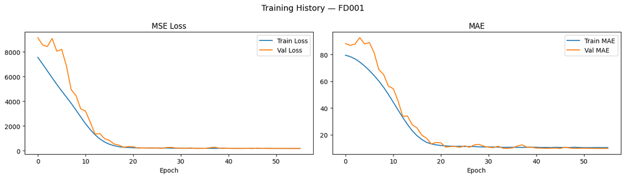

```python
import matplotlib.pyplot as plt

fig, (ax1, ax2) = plt.subplots(1, 2, figsize=(14, 4))

ax1.plot(history.history['loss'],     label='Train Loss')
ax1.plot(history.history['val_loss'], label='Val Loss')
ax1.set_title('MSE Loss')
ax1.set_xlabel('Epoch')
ax1.legend()

ax2.plot(history.history['mae'],     label='Train MAE')
ax2.plot(history.history['val_mae'], label='Val MAE')
ax2.set_title('MAE')
ax2.set_xlabel('Epoch')
ax2.legend()

plt.suptitle('Training History — FD001', fontsize=13)
plt.tight_layout()
plt.savefig('C-MAPSS/CMAPSSData/processed/training_history.png', dpi=150)
plt.show()
```

[output not shown]

```
240/319 ━━━━━━━━━━━━━━━━━━━━ 0s 631us/step
```

[output not shown]

```
319/319 ━━━━━━━━━━━━━━━━━━━━ 2s 4ms/step
========================================
  RMSE : 13.2492
  MAE  : 9.5331
========================================
```

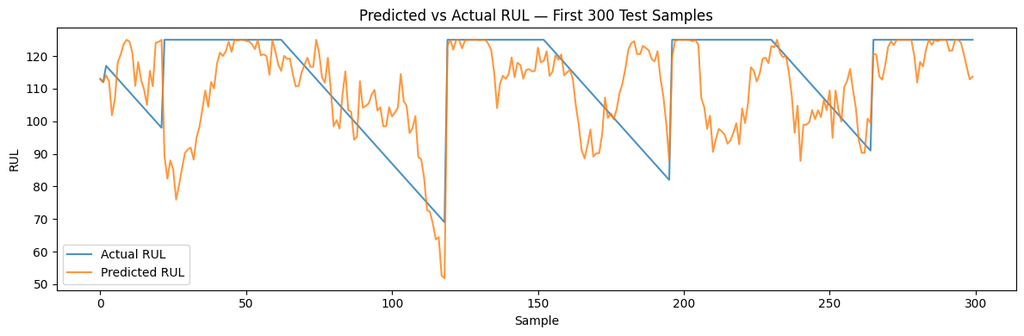

```python
from sklearn.metrics import mean_squared_error

# Predict
y_pred = model.predict(X_test).flatten()

# Clip predictions to valid range
y_pred = np.clip(y_pred, 0, 125)

# Metrics
rmse = np.sqrt(mean_squared_error(y_test, y_pred))
mae  = np.mean(np.abs(y_pred - y_test))

print("=" * 40)
print(f"  RMSE : {rmse:.4f}")
print(f"  MAE  : {mae:.4f}")
print("=" * 40)

# Visualize predicted vs actual
plt.figure(figsize=(12, 4))
plt.plot(y_test[:300],  label='Actual RUL',    alpha=0.8)
plt.plot(y_pred[:300],  label='Predicted RUL', alpha=0.8)
plt.title('Predicted vs Actual RUL — First 300 Test Samples')
plt.xlabel('Sample')
plt.ylabel('RUL')
plt.legend()
plt.tight_layout()
plt.savefig('C-MAPSS/CMAPSSData/processed/rul_predictions.png', dpi=150)
plt.show()
```